# Occupancy models with false-positive misclassification

Jacob Socolar

2023-06-28

```r
# devtools::install_github("stan-dev/cmdstanr")
# devtools::install_github("hyunjimoon/sbc")
# devtools::install_github("jsocolar/flocker")
# install.packages("/users/jacob/dropbox/work/code/flocker", repos = NULL, type = "source")
library(cmdstanr)
library(SBC)
library(flocker)
register_knitr_engine()
set.seed(3)
```

```r
# a generator from the occupancy misclassified distribution
omc_generator_single2 <- function(
    N, rho = .9, covariates
  ){
  # N is the number of sites we are generating;
  #   rho is the probability that any given observed one is a true one.
    det_intercept <- rnorm(1, -1, .5)
    det_slope_unit <- rnorm(1, -1, .5)
    det_slope_visit <- rnorm(1, -1, .5)
    occ_intercept <- rnorm(1, -1, .5)
    occ_slope_unit <- rnorm(1, -1, .5)

    psi <- occ_intercept + occ_slope_unit * covariates$uc1
    theta <- matrix(
      det_intercept + det_slope_unit * covariates$uc1 + det_slope_visit * covariates$ec1,
      nrow = N
    )

    true_occ <- rbinom(N, 1, boot::inv.logit(psi))

    expected_prop_ones <- sum(boot::inv.logit(theta) * boot::inv.logit(psi))/(4*N)
    expected_prop_zeros <- 1 - expected_prop_ones
    expected_prop_false_ones <- expected_prop_ones / rho - expected_prop_ones
    pfo <- expected_prop_false_ones / expected_prop_zeros
    assertthat::assert_that(pfo < 1)

    obs <- true_occ * flocker:::new_matrix(theta, rbinom(N*4, 1, boot::inv.logit(theta)))
    for(i in 1:N){
      for(j in 1:4){
        if(runif(1) < pfo){
          obs[i, j] <- 1
        }
        if(obs[i, j] == 1){
          obs[i, j] <- rho
        }
      }
    }


  # format for return
  list(
    variables = list(
      `b[1]` = det_intercept,
      `b[2]` = det_slope_unit,
      `b[3]` = det_slope_visit,
      `b_occ[1]` = occ_intercept,
      `b_occ[2]` = occ_slope_unit
    ),
    generated = flocker_standata(
      f_occ = ~ 0 + Intercept + uc1,
      f_det = ~ 0 + Intercept + uc1 + ec1,
      flocker_data = make_flocker_data(
        obs,
        unit_covs = data.frame(uc1 = covariates$uc1),
        event_covs = list(ec1 = flocker:::new_matrix(obs, covariates$ec1)),
        fp = TRUE,
        fop = flocker:::new_matrix(obs, 0)
        ),
      fp = TRUE
    )
  )
}
```

```stan
// generated with brms 2.19.0
functions {
    // Emission likelihood given that the true state is zero
  real emission_0_fp(array[] real zol){
    // zol gives the likelihood of the observation given a true zero.
    real out = sum(log(zol)); // the likelihood when the true history is all zeros
    return(out);
  }
    // emission likelihood given that state equals one
  real emission_1_fp(array[] real fp, row_vector det, array[] real zl) {
    // fp gives the fp prob
    // det gives logit-detection probabilities
    // zl gives the likelihood of the observation given a true zero

    int n = size(fp); // number of reps
    real out = 0;
    for(i in 1:n){
      real ll_true_zero = log(zl[i]) + bernoulli_logit_lpmf(0 | det[i]);
      if(fp[i] == 0){
        out += ll_true_zero;  // a true 1 cannot yield an observed 0
      } else {
        real ll_true_one = bernoulli_logit_lpmf(1 | det[i]);
        out += log_sum_exp(ll_true_zero, ll_true_one);
      }
    }
    return(out);
  }

  real occupancy_single_fp_lpdf(
    vector fp, // fp data
    vector mu, // lin pred for detection
    vector occ, // lin pred for occupancy. Elements after vint1[1] irrelevant.
    array[] int vint1, // # units (n_unit). Elements after 1 irrelevant.
    array[] int vint2, // # sampling events per unit (n_rep). Elements after vint1[1] irrelevant.
    array[] int vint3, // Indicator for > 0 certain detections (Q). Elements after vint1[1] irrelevant.

  // indices for jth repeated sampling event to each unit (elements after vint1[1] irrelevant):
    array[] int vint4,
    array[] int vint5,
    array[] int vint6,
    array[] int vint7,
    real prop_ones_true
  ) {
  // Create array of the rep indices that correspond to each unit.
    array[vint1[1], 4] int index_array;
      index_array[,1] = vint4[1:vint1[1]];
      index_array[,2] = vint5[1:vint1[1]];
      index_array[,3] = vint6[1:vint1[1]];
      index_array[,4] = vint7[1:vint1[1]];

  // find expected number of real ones
    real eno = 0;
    for(i in 1:vint1[1]){
      array[vint2[i]] int indices = index_array[i, 1:vint2[i]];
      eno += sum(inv_logit(mu[indices])) * inv_logit(occ[i]);
    }

  // expected number of real zeros
    int N = size(mu);
    real enz = N - eno;

  // expected number of false ones
    real excess_ones = (eno / prop_ones_true) - eno;

  // likelihoods given true zero for 0 and 1
    real vr1 = excess_ones / enz; // population prop of true 0s that are misclassified
    real vr0 = 1 - vr1; // population prop of true 0s that are not misclassified


    array[N] real vr;
    for(i in 1:N){
      if(fp[i] == 0){
        vr[i] = vr0;
      } else {
        vr[i] = vr1;
      }
    }

  // Initialize and compute log-likelihood
    real lp = 0;
    for (i in 1:vint1[1]) {
      array[vint2[i]] int indices = index_array[i, 1:vint2[i]];
        lp += log_sum_exp(
          // case where there site is occupied
          bernoulli_logit_lpmf(1 | occ[i]) +
            emission_1_fp(to_array_1d(fp[indices]), to_row_vector(mu[indices]), vr[indices]),
          // case where site is unoccupied
          bernoulli_logit_lpmf(0 | occ[i]) +
            emission_0_fp(to_array_1d(vr[indices]))
        );
    }
    return(lp);
  }

}
data {
  int<lower=1> N;  // total number of observations
  vector[N] Y;  // response variable
  // data for custom real vectors
  int vint1[N];
  // data for custom integer vectors
  int vint2[N];
  // data for custom integer vectors
  int vint3[N];
  // data for custom integer vectors
  int vint4[N];
  // data for custom integer vectors
  int vint5[N];
  // data for custom integer vectors
  int vint6[N];
  // data for custom integer vectors
  int vint7[N];
  int<lower=1> K;  // number of population-level effects
  matrix[N, K] X;  // population-level design matrix
  int<lower=1> K_occ;  // number of population-level effects
  matrix[N, K_occ] X_occ;  // population-level design matrix
  int prior_only;  // should the likelihood be ignored?
}
transformed data {
  // get the expected number of false ones per apparent one
  real exp_true_ones = 0;
  int n_apparent_ones = 0;

  for(i in 1:N){
    if(Y[i] > 0){
      n_apparent_ones += 1;
      exp_true_ones += Y[i];
    }
  }
  real<lower=0, upper=1> prop_ones_true = exp_true_ones / n_apparent_ones;
}
parameters {
  vector[K] b;  // population-level effects
  vector[K_occ] b_occ;  // population-level effects
}
transformed parameters {
  real lprior = 0;  // prior contributions to the log posterior
  lprior += normal_lpdf(b[1] | -1,.5);
  lprior += normal_lpdf(b[2] | -1,.5);
  lprior += normal_lpdf(b[3] | -1,.5);
  lprior += normal_lpdf(b_occ[1] | -1,.5);
  lprior += normal_lpdf(b_occ[2] | -1,.5);
}
model {
  // likelihood including constants
  if (!prior_only) {
    // initialize linear predictor term
    vector[N] mu = rep_vector(0.0, N);
    // initialize linear predictor term
    vector[N] occ = rep_vector(0.0, N);
    mu += X * b;
    occ += X_occ * b_occ;
    target += occupancy_single_fp_lpdf(Y | mu, occ, vint1, vint2, vint3, vint4, vint5, vint6, vint7, prop_ones_true);
  }
  // priors including constants
  target += lprior;
}
generated quantities {
}
```

```r
n_sims <- 200
omc_generator <- SBC_generator_function(
  omc_generator_single2,
  N = 500,
  rho = .8,
  covariates =
    list(
      ec1 = rnorm(500*4),
      uc1 = rnorm(500)
    )
  )
omc_dataset <- suppressMessages(
  generate_datasets(omc_generator, n_sims)
)

omc_backend <- SBC_backend_cmdstan_sample(omc_model1)
```

```r
results <- compute_SBC(omc_dataset, omc_backend)
```

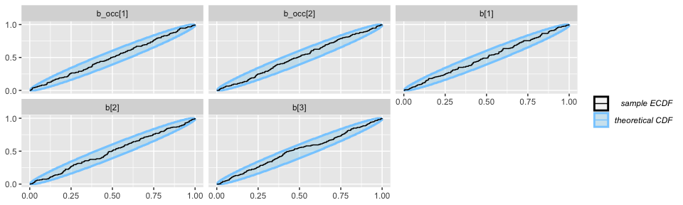

```r
plot_ecdf(results)
```

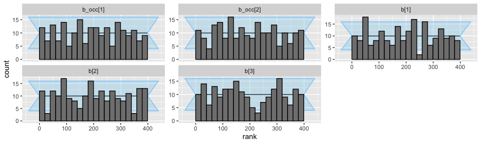

```r
plot_rank_hist(results)
```

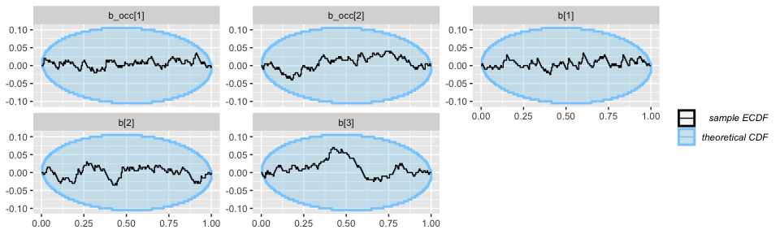

```r
plot_ecdf_diff(results)
```

## Non-uniform misclassification probabilities

In the case where the misclassification probabilities are variable, we assume that we know the exact probability density function for the misclassification probabilities (and their complements) conditional on the observation being classified as a detection. Let $R(x)$ denote this pdf, where $x$ is the complement of the misclassification probability. Then the pdf for misclassification probabilities given that the true observation is a detection is proportional to $xR(x)$ and the pdf given that the true observation is nondetection is proportional to $(1-x)R(x)$.

Thus, the pmf for observed 0’s are unchanged, but the pmf for observed nonzeros picks up extra terms.

We’ll have the likelihood given that a true 0 and the likelihood given a true 1, and both will pick up new terms when the observation is nonzero.

```
int n = size(fp); // number of reps
real out = 0;
for(i in 1:n){
  real ll_true_zero = log(zl[i]) + bernoulli_logit_lpmf(0 | det[i]);
  if(fp[i] == 0){
    out += ll_true_zero;  // a true 1 cannot yield an observed 0
  } else {
    real ll_true_one = bernoulli_logit_lpmf(1 | det[i]) + R1[i]; // R1 is the normalized pdf given a true 1
    out += log_sum_exp(ll_true_zero, ll_true_one);
  }
}
return(out);
```